# CS100 Studio 3

Jonathan Chen

October 6, 2016

Hypothesis 1

```r
friends_vs_happiness <- responses %>%
  select(Number.of.friends, Happiness.in.life) %>%
  arrange(desc(Number.of.friends))
```

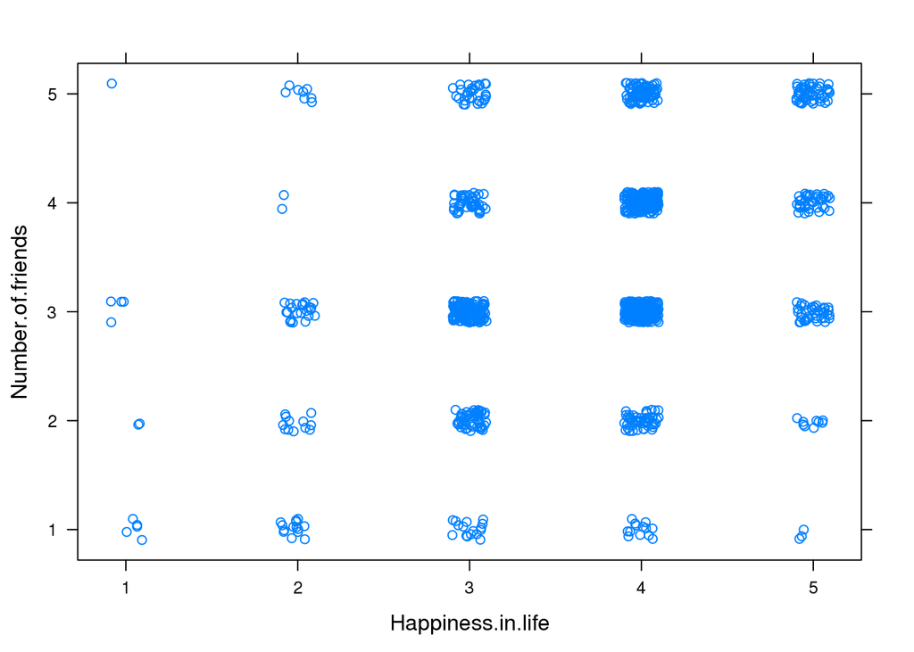

```r
xyplot( Number.of.friends ~ Happiness.in.life, data = friends_vs_happiness, main="", jitter.x=TRUE, jitter.y=TRUE)
```

In general, as number of friends increases, happiness in life also increases. It seems to be a 1:1 linear relationship. However, the relationship is a bit blurry at the higher end of Happiness.in.life and Number.of.friends

Hypothesis 2

```r
gender_vs_happiness <-responses %>%
  select(Gender, Happiness.in.life)
```

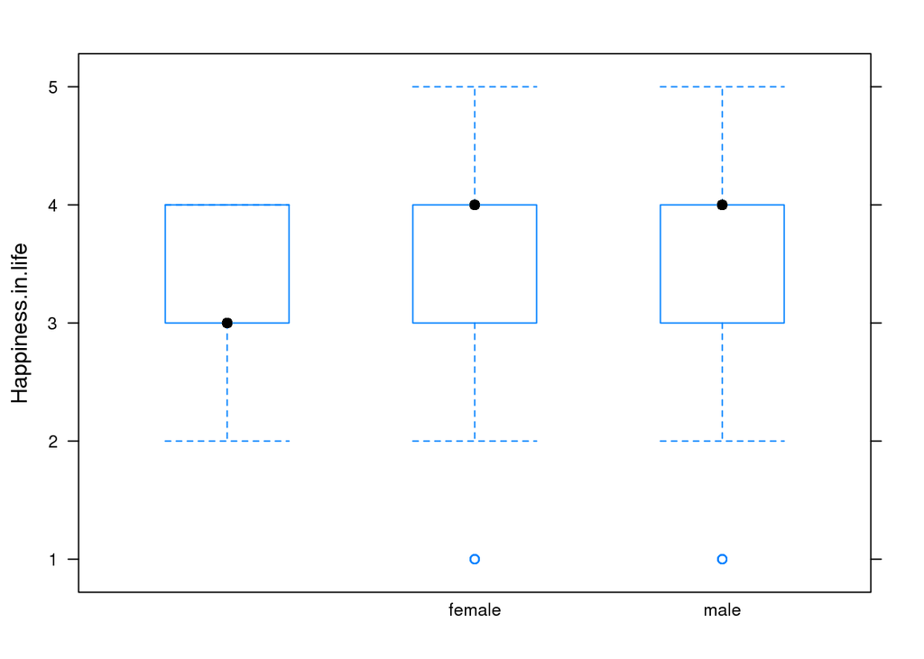

```r
bwplot( Happiness.in.life ~ Gender, data = gender_vs_happiness, main="")
```

According to the box and whisker plot, both males and females are about equal in happiness, with the same mean, median, max, and min. Those who did not provide a gender are slightly unhappier than both males and females. None of them had a happiness of 5.

Hypothesis 3

```r
happiness_vs_age <- responses %>%
  select(Age, Happiness.in.life) %>%
  na.omit() %>%
  group_by(Age) %>%
  summarise(avg_happiness =  mean(Happiness.in.life))
```

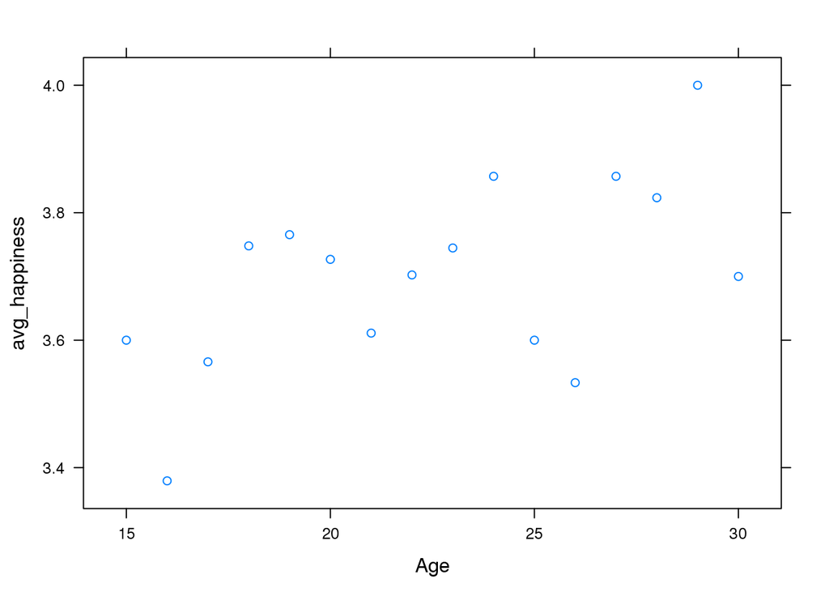

```r
xyplot( avg_happiness ~ Age, data = happiness_vs_age, main="")
```

According to the Scatterplot, it seems as if older people are on average happier. You can sort of see a linear relationship between age and average happiness.

Hypothesis 4

```r
loneliness_vs_alcohol <- responses %>%
  select(Loneliness, Alcohol) %>%
  na.omit()
```

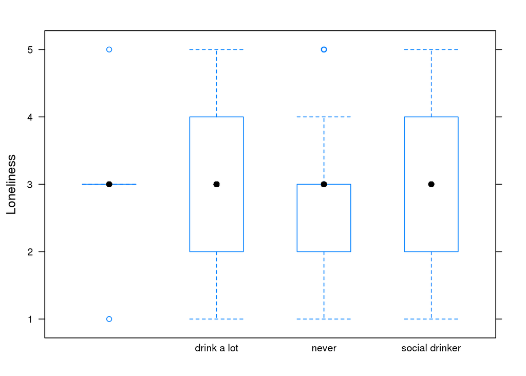

```r
 bwplot( Loneliness ~ Alcohol, data = loneliness_vs_alcohol, main="")
```

My hypothesis is that the more alcohol you consume, the lonelier you are in life. From the box and whisker plot, there seems to be a slight positive relationship between how much alcohol you consume and how lonely you are in life. However, the average loneliness across all people who drink alcohol or not is the same.

Hypothesis 5

```r
health_vs_healthy <- responses %>%
  select(Health, Healthy.eating)
```

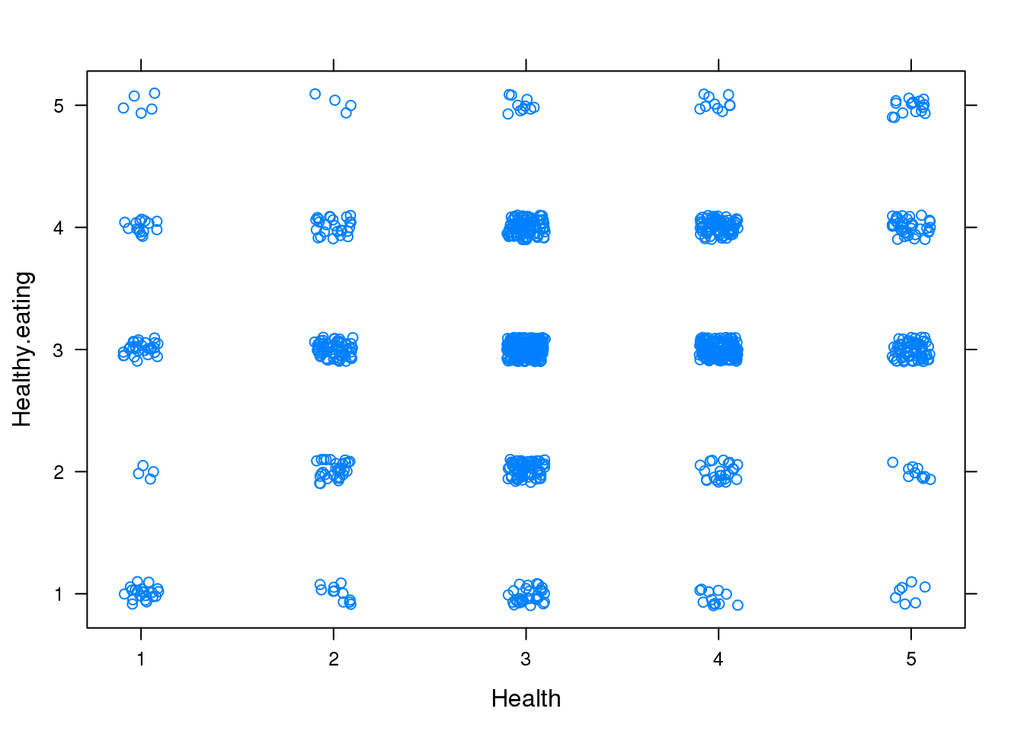

```r
xyplot( Healthy.eating ~ Health, data = health_vs_healthy, main="", jitter.x=TRUE, jitter.y=TRUE)
```

Hypothesis 6 “Education” “Politics”

```r
college_vs_politics <- responses %>%
  select(Education, Politics) %>%
  filter(Education == "college/bachelor degree")
```

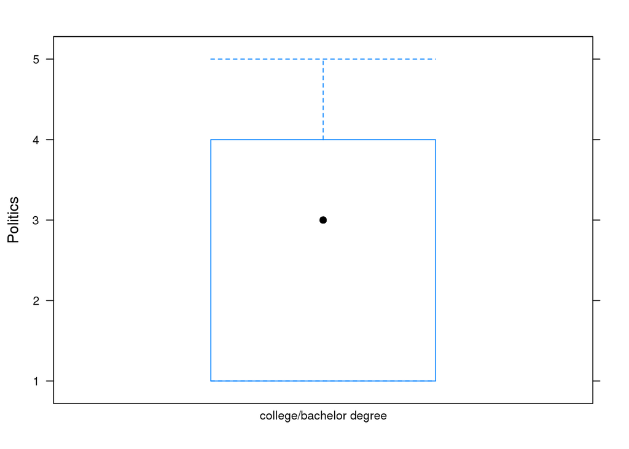

```r
bwplot( Politics ~ Education, data = college_vs_politics, main="")
```

My hypothesis is that those who have bachelor degrees will be very interested in politics. However, the box and whisker plot shows that not as many highly educated people were interested in politics as I thought. The average college graduate felt neutral about politics while most of the graduates were not interested in politics.